# Relationen, Algebra, Diskrete Mathematik

Übungsaufgaben

Martin Zaefferer

# Aussagenlogik

## Tipp

Um beim Üben Ergebnisse oder Zwischenergebnisse zu prüfen, kann es hilfreich sein folgende Seite zu verwenden:

https://www.dcode.fr/boolean-expressions-calculator

Kann zum Beispiel helfen, um zu prüfen, welcher Rechenschritt bei einem falschen Ergebnis schief gegangen ist.

## Aufgabe 1.1

Sind folgende Sätze Aussagen im Sinne der Aussagenlogik, begründen kurz Ihre Antworten.

- “Vorsicht!”

Click zum Öffnen, Click auf Inhalt zum Schließen.

- “Manchmal ist der Himmel blau und manchmal ist der Himmel grau.”

Click zum Öffnen, Click auf Inhalt zum Schließen.

- Irgendwann werden alle Professoren durch KI ersetzt.

Click zum Öffnen, Click auf Inhalt zum Schließen.

- “Gestern war Dienstag.”

Click zum Öffnen, Click auf Inhalt zum Schließen.

## Aufgabe 1.2

Satz: “Manchmal ist der Himmel blau und manchmal ist der Himmel grau”

### a)

Versuchen Sie, diese Aussage durch zwei elementare Einzelaussagen darzustellen.

Click zum Öffnen, Click auf Inhalt zum Schließen.

### b)

Übersetzen Sie bitte den Satz entsprechend in eine aussagenlogische Formel.

Click zum Öffnen, Click auf Inhalt zum Schließen.

## Aufgabe 1.3

Prüfen Sie für die Formeln, ob folgende Eigenschaften vorliegen: Tautologie, widerspruchsvoll, erfüllbar. Verfahren ist egal, versuchen Sie gerne auch mal unterschiedliche Verfahren (Termumformungen, Wahrheitstabelle)

- $F_1(a,b,c)= ((a\mathcal{{\rightarrow}}b)\lor (a \mathcal{{\rightarrow}}c)) \leftrightarrow(a \mathcal{{\rightarrow}}(b \lor c))$

Click zum Öffnen, Click auf Inhalt zum Schließen.

- $F_2(a,b,c)= (b\mathcal{{\rightarrow}}a) \lor (c \mathcal{{\rightarrow}}b)$

Click zum Öffnen, Click auf Inhalt zum Schließen.

- $F_3(a,b)= (a \leftrightarrow\lnot b) \land (b\mathcal{{\rightarrow}}a)$

Click zum Öffnen, Click auf Inhalt zum Schließen.

- $F_4(a,b)= (a \leftrightarrow b) \land \lnot(b\mathcal{{\rightarrow}}a)$

Click zum Öffnen, Click auf Inhalt zum Schließen.

- $F_5(a,b)= (a \leftrightarrow b) \land \lnot(a\mathcal{{\rightarrow}}b)$

Click zum Öffnen, Click auf Inhalt zum Schließen.

- $F_6(a,b)= (a \mathcal{{\rightarrow}}b) \land (b\mathcal{{\rightarrow}}a) \leftrightarrow(a\leftrightarrow b)$

Click zum Öffnen, Click auf Inhalt zum Schließen.

## Aufgabe 1.4

Überführen Sie folgende logische Formel $F$ in eine konjunktive Normalform:

- $F(a,b,c)=(a\lor c \land (a\mathcal{{\rightarrow}}b))$

Click zum Öffnen, Click auf Inhalt zum Schließen.

Und in kKN:

Click zum Öffnen, Click auf Inhalt zum Schließen.

Und in DN:

Click zum Öffnen, Click auf Inhalt zum Schließen.

Und in kDN:

Click zum Öffnen, Click auf Inhalt zum Schließen.

## Aufgabe 1.5

Überführen Sie in kKN:

- $F(a,b,c)=c$

Click zum Öffnen, Click auf Inhalt zum Schließen.

## Aufgabe 1.6

Überführen Sie in kKN:

- $F(a,b)=a \lor b \lor f$

Click zum Öffnen, Click auf Inhalt zum Schließen.

## Aufgabe 1.7

Gegeben sei die folgende Behauptung:

- $(a\lnot b \lor (c\mathcal{{\rightarrow}}d)) (c\lor d)\models (a \mathcal{{\rightarrow}}d) \lor b$

Beweisen oder widerlegen Sie diese Behauptung mithilfe der Resolution.

Dokumentieren Sie ihren Lösungsweg.

Click zum Öffnen, Click auf Inhalt zum Schließen.

## Aufgabe 1.8

Zeigen Sie mit dem Resolutionsverfahren, ob die folgende Behauptung gilt:

- $(a\lnot b \lor (c\mathcal{{\rightarrow}}d)) (c\lor d)\models (a \mathcal{{\rightarrow}}b) \lor a$

Click zum Öffnen, Click auf Inhalt zum Schließen.

## Aufgabe 1.9

Geben Sie ein Beispiel für eine Formel an, die alle drei logischen Variablen a, b und c enthält und widerspruchsvoll ist.

Click zum Öffnen, Click auf Inhalt zum Schließen.

# Mengen

## Aufgabe 2.1

Bestimmen Sie die Mächtigkeit der folgenden Mengen: $A=\{3,6,12\}~~~~~B=\{\emptyset,3,6,12\}~~~~~C=A\cup B~~~~~D=\mathcal{P}(C)~~~~~E=D\setminus B~~~~~F=D\setminus \{B\}$

Click zum Öffnen, Click auf Inhalt zum Schließen.

## Aufgabe 2.2

Gegeben sind die Mengen $A=\{3,6\}~~~~~B=\{9,3\}~~~~~C=\{0,1\}$

Bestimmen Sie:

$D=(A\cup B) \times C \times C$

Click zum Öffnen, Click auf Inhalt zum Schließen.

## Aufgabe 2.3

Geben sie möglichst kurz folgende Menge an: $M=\{x|x\in {\mathbb{R}}\land x \in {\mathbb{N}}\land x>1 \}$

Click zum Öffnen, Click auf Inhalt zum Schließen.

# Relationen

## Aufgabe 3.1

Gegeben sei die Relation $R_{(x=y^3)} \subseteq {\mathbb{R}}\times {\mathbb{R}}$. Das bedeutet, die Relation xRy trifft zu, wenn $(x=y^3)$, mit $x,y \in {\mathbb{R}}$.

Welche der folgenden 4 Eigenschaften treffen zu? Begründen Sie bitte Ihre Antworten kurz.

| Bezeichnung | Bedeutung |
| --- | --- |
| 1. Reflexiv | $\forall x \in M$ gilt $xRx$ |
| 2. Irreflexiv | $\nexists x \in M$ mit $xRx$ |
| 3. Symmetrisch | $\forall x, y \in M$ gilt $xRy \mathcal{{\rightarrow}}yRx$ |
| 4. Asymmetrisch | $\forall x, y \in M$ gilt $xRy \mathcal{{\rightarrow}}\lnot yRx$ |

Click zum Öffnen, Click auf Inhalt zum Schließen.

## Aufgabe 3.2

Gegeben sei die Relation $R_{((x=y^3)\land(x=y))} \subseteq {\mathbb{R}}\times {\mathbb{R}}$. Das bedeutet, die Relation xRy trifft zu, wenn $(x=y^3)\land(x=y)$, mit $x,y \in {\mathbb{R}}$.

Ist diese Relation transitiv? Begründen Sie bitte Ihre Antwort kurz.

Zu Erinnerung, transitiv bedeutet: $\forall x, y, z \in M$ gilt $xRy \land yRz \mathcal{{\rightarrow}}xRz$

Click zum Öffnen, Click auf Inhalt zum Schließen.

## Aufgabe 3.3

Gegeben sei die Relation $R_{(x\land y)} \subseteq {\mathbb{B}}\times {\mathbb{B}}$, mit ${\mathbb{B}}=\{w,f\}$. Die Relation $xRy$ trifft also zu, wenn $x$ und $y$ wahr sind.

Ist diese Relation transitiv? Begründen Sie bitte Ihre Antwort kurz.

Click zum Öffnen, Click auf Inhalt zum Schließen.

## Aufgabe 3.4

### a)

Gegeben sei die Relation $R \subseteq A \times A$, mit $A=\{a,b\}$.

Wenn die Relation aus den Tupeln $R=\{(a,a),(b,b)\}$ besteht:

Ist diese Relation reflexiv, irreflexiv, symmetrisch, asymmetrisch, antisymmetrisch, transitiv, linear konnex?

Click zum Öffnen, Click auf Inhalt zum Schließen.

### b)

Gegeben sei die Relation $R \subseteq B \times B$, mit $B=\{1,2\}$.

Wenn die Relation nur aus dem Tupel $R=\{(1,2)\}$ besteht:

Ist diese Relation reflexiv, irreflexiv, symmetrisch, asymmetrisch, antisymmetrisch, transitiv, linear konnex?

Click zum Öffnen, Click auf Inhalt zum Schließen.

## Aufgabe 3.5

Ist die Relation $R=\{(12,z)\}$ symmetrisch? Warum?

Click zum Öffnen, Click auf Inhalt zum Schließen.

## Aufgabe 3.6

Ist die Relation $R=\{(0,0)\}$ transitiv?

Click zum Öffnen, Click auf Inhalt zum Schließen.

## Aufgabe 3.7

Ist die Relation $R=\{(8,9)\}$ transitiv?

Click zum Öffnen, Click auf Inhalt zum Schließen.

# Abbildungen

## Aufgabe 4.1

Handelt es sich bei der folgend graphisch dargestellten Zuordnung von der Menge D zur Menge W um eine Abbildung? Warum / warum nicht?

[figure not shown]

Click zum Öffnen, Click auf Inhalt zum Schließen.

## Aufgabe 4.2

Handelt es sich bei der folgend graphisch dargestellten Zuordnung von der Menge D zur Menge W um eine Abbildung? Warum / warum nicht?

[figure not shown]

Click zum Öffnen, Click auf Inhalt zum Schließen.

## Aufgabe 4.3

Erzeugen Sie eine grafische Darstellung einer Abbildung von der Menge $D=\{a,b,c,d\}$ zur Menge $W=\{q,e,d\}$, die surjektiv aber nicht injektiv ist.

[figure not shown]

Abbildung, da linksvollständig und rechtseindeutig (bei jedem Element in D startet ein Pfeil). Surjektiv, da rechtsvollständig (es endet bei jedem Element in W min. ein Pfeil). Nicht injektiv, da nicht linkseindeutig (bei e enden zwei Pfeile).

Click zum Öffnen, Click auf Inhalt zum Schließen.

## Aufgabe 4.4

Gegeben sei die Abbildung $f: D \mathcal{{\rightarrow}}W$ mit $x ↦ f(x)$ und $f(x) = \sqrt{x-1}$.

Die Definitionsmenge ist das Intervall $D=[1,\infty)$. Die Wertemenge $W=[0,\infty)$ seien alle positiven reellen Zahlen, inklusive Null.

Ist die Abbildung $f$ injektiv / surjektiv / bijektiv?

Click zum Öffnen, Click auf Inhalt zum Schließen.

## Aufgabe 4.5

Können Sie eine Funktion $f: {\mathbb{R}}\mathcal{{\rightarrow}}{\mathbb{R}}$ notieren, die injektiv ist, aber weder streng monoton steigend, noch streng monoton fallend?

Click zum Öffnen, Click auf Inhalt zum Schließen.

## Aufgabe 4.6

In welchem Fall ist die Sinusfunktion surjektiv?

Click zum Öffnen, Click auf Inhalt zum Schließen.

## Aufgabe 4.7

Gegeben sei die Funktionsvorschrift $f(x)=(x-1)^2 +2$ für die Abbildung $x ↦ f(x)$. Für welche Mengen $f: D \mathcal{{\rightarrow}}W$ ist diese Funktion bijektiv?

Es handelt sich um eine quadratische Funktion, mit einer Verschiebung um 1 auf der x-Achse und 2 auf der y-Achse. Damit ergeben sich Funktionswerte von 2 oder größer, und jeweils gleiche Funktionswerte (symmetrisch zu $x=1$, z.B. führen $x=0$ und $x=2$ zum selben Funktionswert). Eine bijektive Funktion sollte sich also ergeben für $D=[1,\infty)$ und $W=[2,\infty)$  
Nur zur Ergänzung:

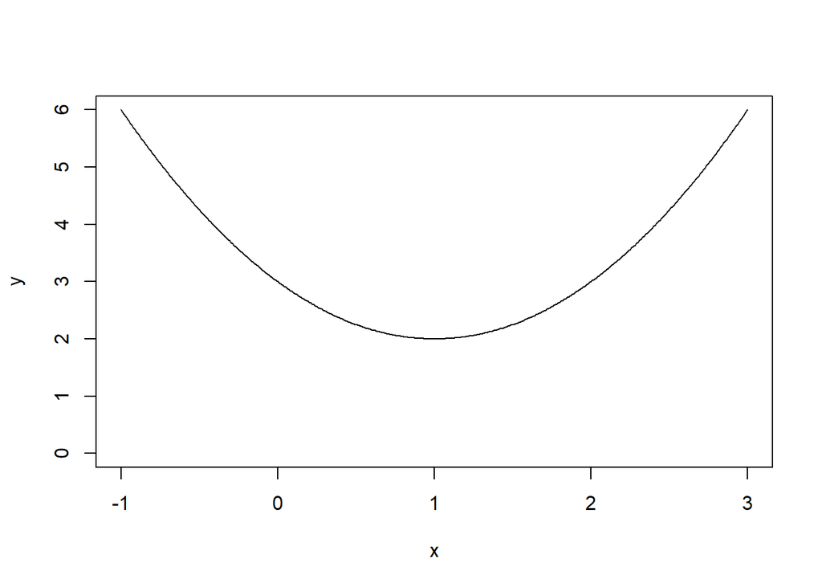

Eine ebenfalls gültige Antwort wäre $D=\{1\}$ und $W=\{2\}$

Click zum Öffnen, Click auf Inhalt zum Schließen.

## Aufgabe 4.8

Die Formel $x^2+y^2=r^2$ ist die Kreisgleichung für einen Kreis mit Radius $r$ (x und y sind Koordinaten von Punkten auf dem Kreis).  
Es ergibt sich hieraus mit $f: {\mathbb{R}}\mathcal{{\rightarrow}}{\mathbb{R}}$ und $y=f(x)=\sqrt{r^2-x^2}$ eine Funktion, die den Halbkreis beschreibt. Warum beschreibt diese Funktion nur einen Halbkreis, nicht den ganzen? Ist die Funktion injektiv/surjektiv/bijektiv?

Der gesamte Kreis kann mit einer Funktion nicht beschrieben werden, da hierbei einem x zwei y-Werte zugeordnet werden müssten. Die Funktion ist nicht injektiv, da auf jeweils einen y-Wert von zwei x-Werten abgebildet wird (symmetrisch zur y-Achse). Die Funktion ist nicht surjektiv, da für $y<0$ und $y>r$ keine Werte abgebildet werden. Somit ist f auch nicht bijektiv.  
Nur zur Ergänzung:

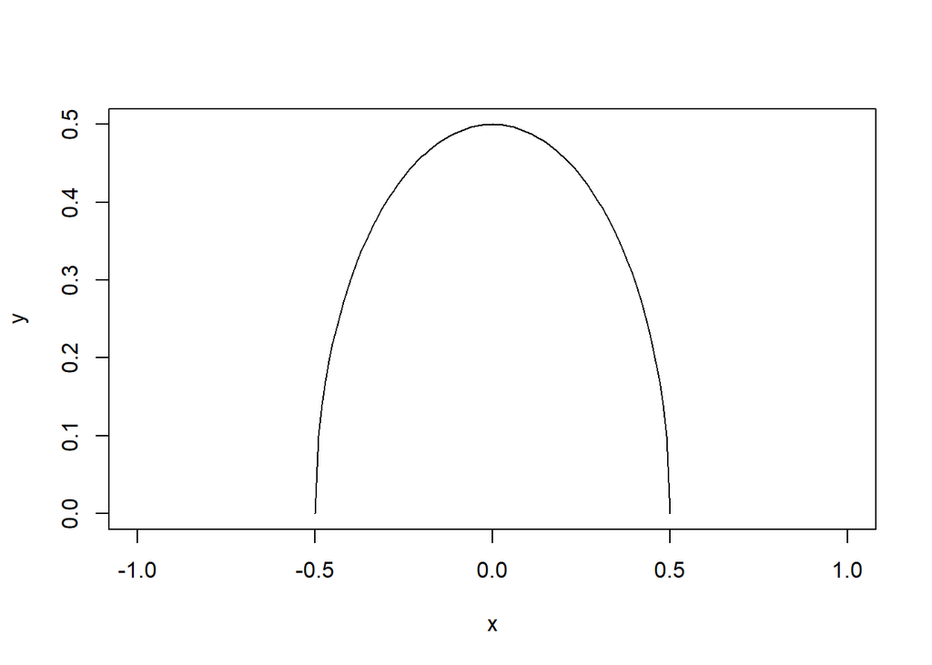

Click zum Öffnen, Click auf Inhalt zum Schließen.

# Relationenalgebra

## Aufgabe 5.1

Gegeben seien folgende Relationen $r_1$ und $r_2$:

| $r_1$ | $n$ | $x_1$ | $x_2$ | $x_3$ |  |
| --- | --- | --- | --- | --- | --- |
|  | 1 | 0 | x | ab |  |
|  | 2 | 0 | y | ac |  |
|  | 3 | 1 | z | ab |  |
|  | 4 | 0 | y | ac |  |
|  | 5 | 0 | y | abc |  |

| $r_2$ | $n$ | $x_1$ | $x_4$ | $x_5$ | $x_6$ |
| --- | --- | --- | --- | --- | --- |
|  | 1 | 0 | 1 | 9 | f |
|  | 1 | 0 | 1 | 8 | f |
|  | 4 | 1 | 4 | 7 | g |
|  | 3 | 1 | 3 | 6 | h |
|  | 2 | 0 | 3 | 7 | h |
|  | 2 | 0 | 4 | 7 | h |
|  | 3 | 0 | 2 | 7 | h |

Bestimmen Sie die Relation $r_3$ mit:

$$r_3=
\Pi_{\{n,x_5,x_6\}}
\left(
\sigma_{(x_1\neq 1) \land (n<5)}(r_1) ⋈ \sigma_{x_1\neq1}(r_2)
\right)$$

(Anmerkung: ⋈ meint natural join)

Click zum Öffnen, Click auf Inhalt zum Schließen.

## Aufgabe 5.2

Gegeben seien folgende Relationen $r_1$ und $r_2$:

| $r_1$ | $n$ | $x_1$ | $x_2$ | $x_3$ |  |
| --- | --- | --- | --- | --- | --- |
|  | 1 | 0 | x | ab |  |
|  | 2 | 0 | y | ac |  |
|  | 3 | 1 | z | ab |  |
|  | 4 | 0 | y | ac |  |
|  | 5 | 0 | y | abc |  |

| $r_2$ | $n$ | $x_1$ | $x_4$ | $x_5$ | $x_6$ |
| --- | --- | --- | --- | --- | --- |
|  | 1 | 0 | 1 | 9 | f |
|  | 1 | 0 | 1 | 8 | f |
|  | 4 | 1 | 4 | 7 | g |
|  | 3 | 1 | 3 | 6 | h |
|  | 2 | 0 | 3 | 7 | h |
|  | 2 | 0 | 4 | 7 | h |
|  | 3 | 0 | 2 | 7 | h |

Bestimmen Sie die Relation $r_3$ mit:

$$r_3=
\sigma_{(x_1\neq 1) \land (n<5)}\left(r_1 ⋈ \Pi_{\{n,x_5,x_6\}}(r_2)
\right)$$

(Anmerkung: ⋈ meint natural join)

Click zum Öffnen, Click auf Inhalt zum Schließen.

## Aufgabe 5.3

Gegeben seien folgende Relationen $r_1$ und $r_2$:

| $r_1$ | $n$ | $x_1$ | $x_2$ | $x_3$ |
| --- | --- | --- | --- | --- |
|  | 1 | 0 | x | ab |
|  | 2 | 0 | y | ac |
|  | 3 | 1 | z | ab |
|  | 4 | 0 | y | ac |

| $r_2$ | $n$ | $x_1$ | $x_2$ | $x_3$ |
| --- | --- | --- | --- | --- |
|  | 1 | 0 | x | ab |
|  | 2 | 0 | y | ab |

Bestimmen Sie die Relation $r_3$ mit:

$$r_3= r_1 \cap r_2$$

Click zum Öffnen, Click auf Inhalt zum Schließen.

# Schaltalgebra

## Aufgabe 6.1

Gegeben ist für die Schaltfunktion $F(a,b,c)$ die folgende Wertetabelle

| a | b | c | $F$ |
| --- | --- | --- | --- |
| 0 | 0 | 0 | 1 |
| 0 | 0 | 1 | 0 |
| 0 | 1 | 0 | 0 |
| 0 | 1 | 1 | 0 |
| 1 | 0 | 0 | 0 |
| 1 | 0 | 1 | 0 |
| 1 | 1 | 0 | 0 |
| 1 | 1 | 1 | 1 |

Lesen Sie aus der Tabelle jeweils die kanonische Disjunktive Normalform (kDN) und die kanonische Konjunktive Normalform (kKN) zu $F$ ab.

Bestimmen Sie dann mit Hilfe des KV-Diagramms die Disjunktive Minimalform (DM).

Click zum Öffnen, Click auf Inhalt zum Schließen.  
-

## Aufgabe 6.2

Gegeben ist für die Schaltfunktion $F(a,b,c)$ die folgende Wertetabelle

| a | b | c | $F$ |
| --- | --- | --- | --- |
| 0 | 0 | 0 | 1 |
| 0 | 0 | 1 | 0 |
| 0 | 1 | 0 | 1 |
| 0 | 1 | 1 | 0 |
| 1 | 0 | 0 | 1 |
| 1 | 0 | 1 | 0 |
| 1 | 1 | 0 | 1 |
| 1 | 1 | 1 | 0 |

Lesen Sie aus der Tabelle jeweils die kanonische Disjunktive Normalform (kDN) und die kanonische Konjunktive Normalform (kKN) zu $F$ ab.

Bestimmen Sie dann mit Hilfe des KV-Diagramms die Disjunktive Minimalform (DM).

Click zum Öffnen, Click auf Inhalt zum Schließen.  
-

## Aufgabe 6.3

Gegeben ist für die Schaltfunktion $F(a,b,c,d)$ die folgende Wertetabelle

| a | b | c | d | $F$ |
| --- | --- | --- | --- | --- |
| 0 | 0 | 0 | 0 | 0 |
| 0 | 0 | 0 | 1 | 0 |
| 0 | 0 | 1 | 0 | 1 |
| 0 | 0 | 1 | 1 | 0 |
| 0 | 1 | 0 | 0 | 0 |
| 0 | 1 | 0 | 1 | 0 |
| 0 | 1 | 1 | 0 | 0 |
| 0 | 1 | 1 | 1 | 0 |
| 1 | 0 | 0 | 0 | 1 |
| 1 | 0 | 0 | 1 | 1 |
| 1 | 0 | 1 | 0 | 1 |
| 1 | 0 | 1 | 1 | 0 |
| 1 | 1 | 0 | 0 | 0 |
| 1 | 1 | 0 | 1 | 0 |
| 1 | 1 | 1 | 0 | 1 |
| 1 | 1 | 1 | 1 | 1 |

Lesen Sie aus der Tabelle die kanonische Disjunktive Normalform (kDN) zu $F$ ab. Bestimmen Sie dann mit Hilfe des KV-Diagramms die Disjunktive Minimalform (DM).

Click zum Öffnen, Click auf Inhalt zum Schließen.  
-

# Graphen

## Aufgabe 7.1

Zeichnen Sie den ungerichteten Graphen ohne Gewichte zu folgender Adjazenzmatrix. Bezeichnen Sie die Knoten Spaltenweise mit 1,2,3,4.

$\begin{pmatrix} 0 & 0 & 1 & 1 \\ 0 & 0 & 1 & 1 \\ 1 & 1 & 0 & 1 \\ 1 & 1 & 1 & 0 \\ \end{pmatrix}$

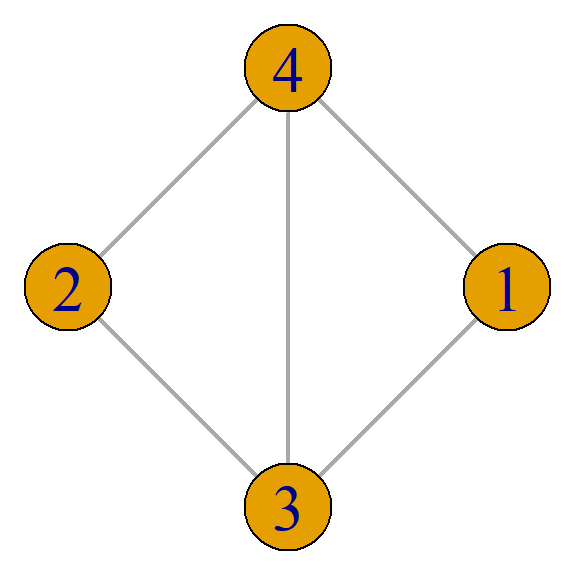

Click zum Öffnen, Click auf Inhalt zum Schließen.

## Aufgabe 7.2

Zeichnen Sie den gerichteten Graphen ohne Gewichte zu folgender Adjazenzmatrix. Bezeichnen Sie die Knoten Spaltenweise mit 1,2,3,4.

$\begin{pmatrix} 0 & 0 & 0 & 1 \\ 0 & 0 & 0 & 1 \\ 1 & 1 & 0 & 1 \\ 1 & 1 & 1 & 0 \\ \end{pmatrix}$

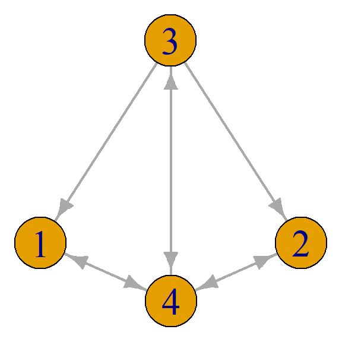

Click zum Öffnen, Click auf Inhalt zum Schließen.

## Aufgabe 7.3

Geben Sie die Adjazenzmatrix und Adjazentliste zu folgendem Graphen an.

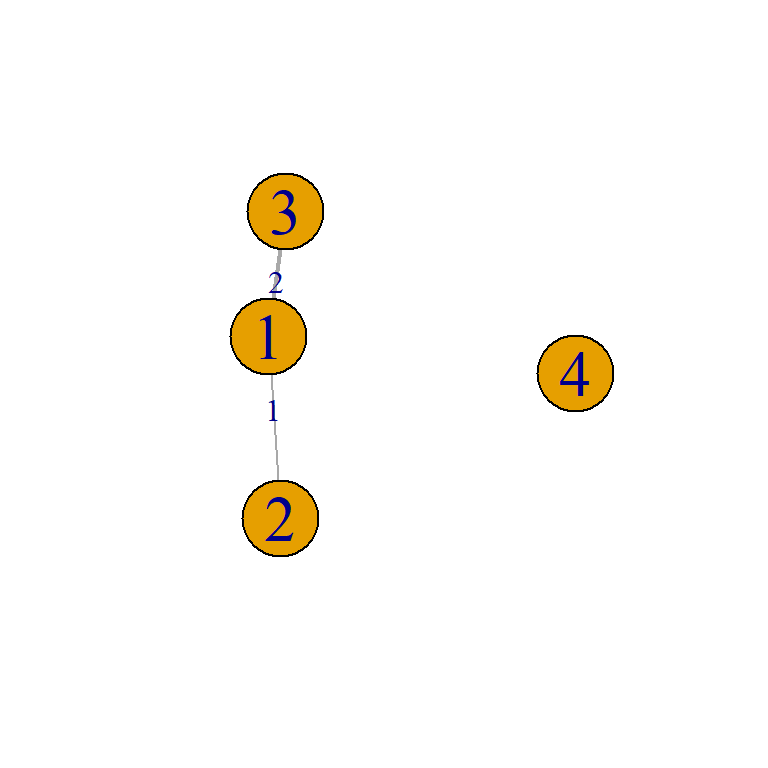

Click zum Öffnen, Click auf Inhalt zum Schließen.

## Aufgabe 7.4

Bei einem klassischen Transportproblem müssen von einer gegebenen Zahl von Lieferanten Produkte an eine gegebene Zahl von Empfängern geliefert werden. Je nach Lieferant und Empfänger ergeben sich für jede Lieferung unterschiedliche Kosten.

Stellen Sie ein Beispiel des Transportproblems zeichnerisch als Graph dar. Um was für einen Graphentyp handelt es sich?

Bipartiter Graph. Hier: Blau alle Lieferanten, Grün alle Empfänger.

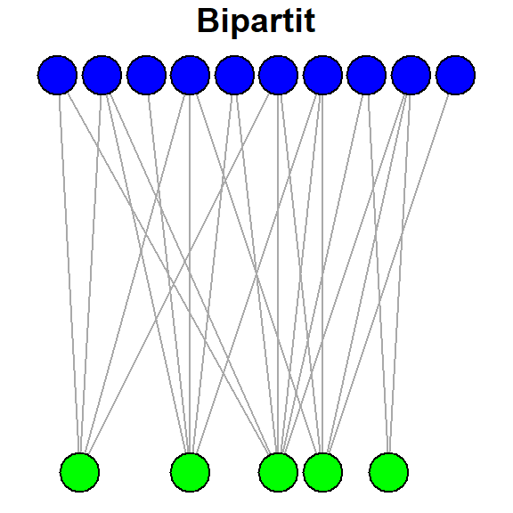

Click zum Öffnen, Click auf Inhalt zum Schließen.

## Aufgabe 7.5

### a)

Zeichnen Sie ein Beispiel eines vollständigen, ungerichteten Graphen

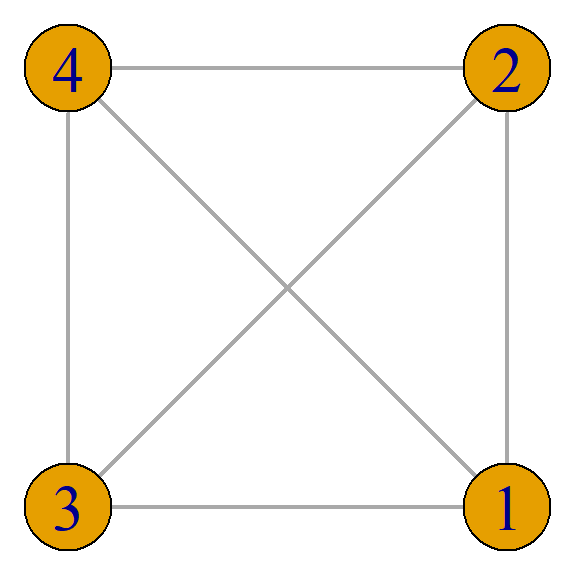

Click zum Öffnen, Click auf Inhalt zum Schließen.

### b)

Geben Sie die Adjazenzmatrix für einen leeren Graphen an

Click zum Öffnen, Click auf Inhalt zum Schließen.

### c)

Zeichnen Sie einen kleinstmöglichen Graphen, der zwei Knoten mit Knotengrad von 3 enthält. Markieren Sie diese beiden Knoten.

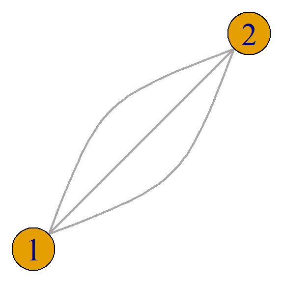

Click zum Öffnen, Click auf Inhalt zum Schließen.

## Aufgabe 7.6

- Zuvor haben wir das Transportproblem als Graphen interpretiert. Können wir dieses Problem mit Dijkstra lösen?

Click zum Öffnen, Click auf Inhalt zum Schließen.

## Aufgabe 7.7

- Sie sitzen im Auto und wollen den kürzesten Pfad zur nächsten Tankstelle bestimmen.
  - In welchem Fall würden Sie hierfür A* benutzen?
  - In welchem Fall würden Sie hierfür Dijkstra benutzen?

Click zum Öffnen, Click auf Inhalt zum Schließen.

## Aufgabe 7.8

- Erläutern Sie, wie der Updateschritt des A* Algorithmus funktioniert.

Click zum Öffnen, Click auf Inhalt zum Schließen.

- Welches sind die wichtigsten Unterschiede zwischen A* und Dijkstra?

Click zum Öffnen, Click auf Inhalt zum Schließen.

- Wie lässt sich A* am einfachsten zu Dijkstra umändern?

Click zum Öffnen, Click auf Inhalt zum Schließen.

## Aufgabe 7.9

Welcher Pfad ist hier der kürzeste (überall gleiche Gewichte), von Knoten 1 zu 6? Führen Sie hierzu den Dijkstra Algorithmus durch.

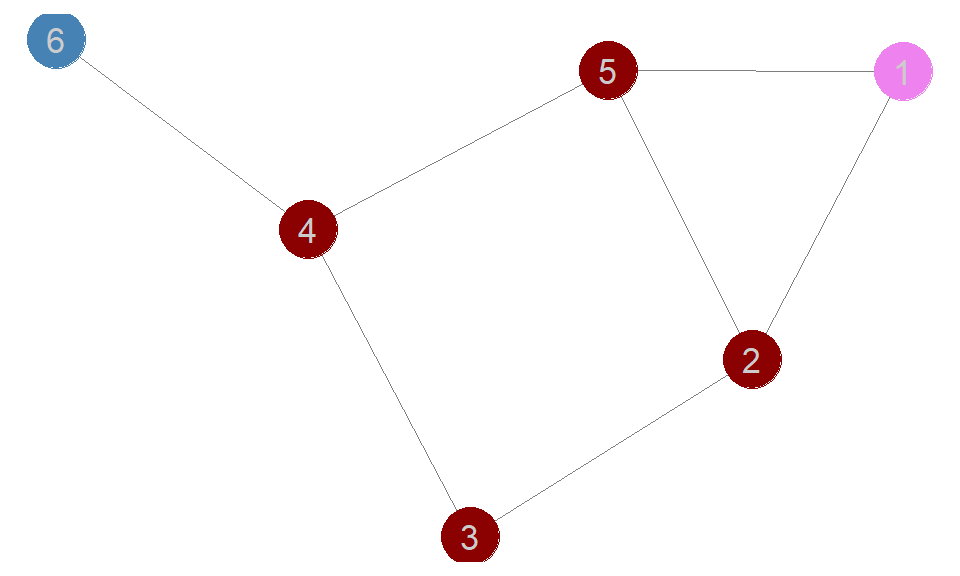

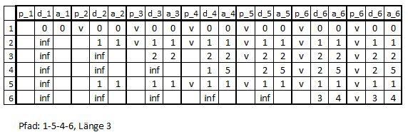

Click zum Öffnen, Click auf Inhalt zum Schließen.

## Aufgabe 7.10

Führen Sie Dijkstra UND A* für das Ravensburg/Immenstaat Beispiel durch. Nehmen Sie dabei folgende Heuristik-Werte an:

- Ravensburg-Immenstaad: 30
- Tettnang-Immenstaad: 25
- Meckenbeuren-Immenstaad: 20
- Friedrichshafen-Immenstaad: 10
- Oberteuringen-Immenstaad: 15
- Markdorf-Immenstaad: 5

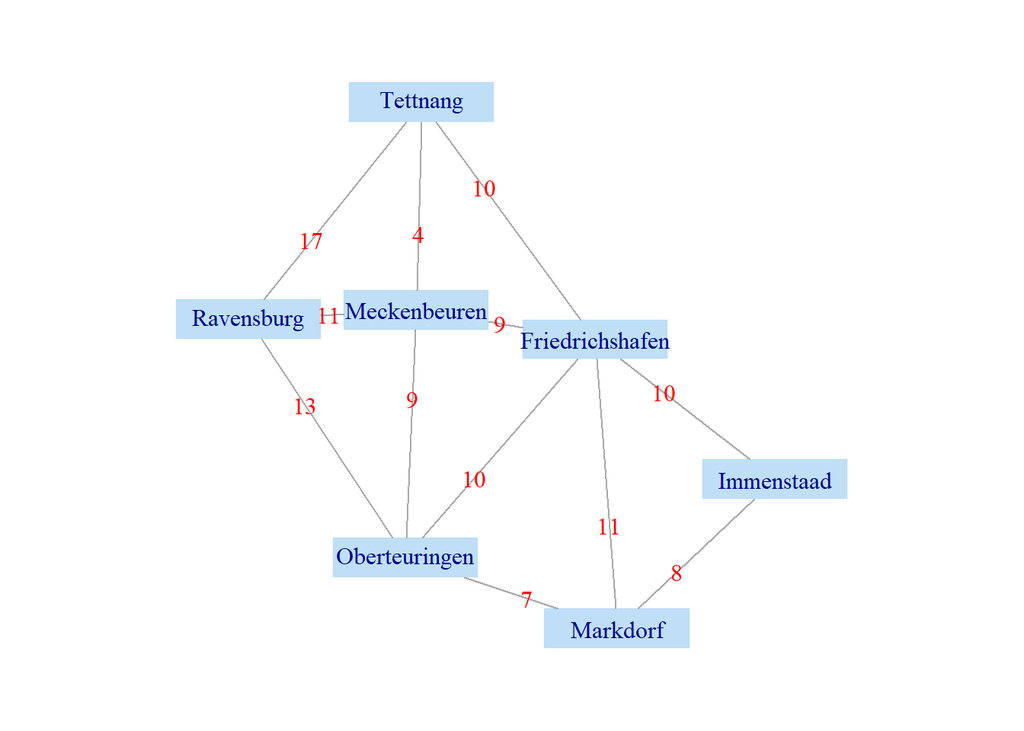

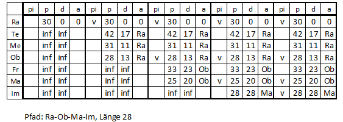

Click zum Öffnen, Click auf Inhalt zum Schließen.

## Aufgabe 7.11

- Ermitteln Sie zu gegebener Gewichtsmatrix $A$ eine möglichst kurze TSP Tour und deren Länge mit dem Nearest Neighbour Algorithmus, startend in Knoten 1.

$$A = \begin{pmatrix}
\infty & 4 & 3 & 4 & 4 & 6 \\
4 & \infty & 2 & 6 & 3 & 5 \\
3 & 2 & \infty & 4 & 1 & 3 \\
4 & 6 & 4 & \infty & 5 & 4 \\
4 & 3 & 1 & 5 & \infty & 2 \\
6 & 5 & 3 & 4 & 2 & \infty
\end{pmatrix}$$

Click zum Öffnen, Click auf Inhalt zum Schließen.

## Aufgabe 7.12

- Ermitteln Sie zu gegebener Gewichtsmatrix $A$ eine möglichst kurze TSP Tour mit dem Nearest Neighbour Algorithmus, startend in Knoten 2.

$$A = \begin{pmatrix}
\infty & 4 & 3 & 4 & 4 & 6 \\
4 & \infty & 2 & 6 & 3 & 5 \\
3 & 2 & \infty & 4 & 1 & 3 \\
4 & 6 & 4 & \infty & 5 & 4 \\
4 & 3 & 1 & 5 & \infty & 2 \\
6 & 5 & 3 & 4 & 2 & \infty
\end{pmatrix}$$

Click zum Öffnen, Click auf Inhalt zum Schließen.